# Explore and Summarize Data by Satvik Sachdev

This project will apply exploratory data analysis techniques using R to analyze chemical properties of Red Wines in order to answer the following question: - “Which chemical properties influence the quality of red wines?”

The dataset contains information about 1,599 red wines with 11 variables on the chemical properties of the wine.

The quality of each wine is rated between 0(very bad) and 10(very excellent) by at least 3 wine experts.

# Data Exploration

### Summary of dataset

```
##  [1] "X"                    "fixed.acidity"        "volatile.acidity"
##  [4] "citric.acid"          "residual.sugar"       "chlorides"
##  [7] "free.sulfur.dioxide"  "total.sulfur.dioxide" "density"
## [10] "pH"                   "sulphates"            "alcohol"
## [13] "quality"
```

```
## [1] 1599   13
```

```
## 'data.frame':    1599 obs. of  13 variables:
##  $ X                   : int  1 2 3 4 5 6 7 8 9 10 ...
##  $ fixed.acidity       : num  7.4 7.8 7.8 11.2 7.4 7.4 7.9 7.3 7.8 7.5 ...
##  $ volatile.acidity    : num  0.7 0.88 0.76 0.28 0.7 0.66 0.6 0.65 0.58 0.5 ...
##  $ citric.acid         : num  0 0 0.04 0.56 0 0 0.06 0 0.02 0.36 ...
##  $ residual.sugar      : num  1.9 2.6 2.3 1.9 1.9 1.8 1.6 1.2 2 6.1 ...
##  $ chlorides           : num  0.076 0.098 0.092 0.075 0.076 0.075 0.069 0.065 0.073 0.071 ...
##  $ free.sulfur.dioxide : num  11 25 15 17 11 13 15 15 9 17 ...
##  $ total.sulfur.dioxide: num  34 67 54 60 34 40 59 21 18 102 ...
##  $ density             : num  0.998 0.997 0.997 0.998 0.998 ...
##  $ pH                  : num  3.51 3.2 3.26 3.16 3.51 3.51 3.3 3.39 3.36 3.35 ...
##  $ sulphates           : num  0.56 0.68 0.65 0.58 0.56 0.56 0.46 0.47 0.57 0.8 ...
##  $ alcohol             : num  9.4 9.8 9.8 9.8 9.4 9.4 9.4 10 9.5 10.5 ...
##  $ quality             : int  5 5 5 6 5 5 5 7 7 5 ...
```

# Univariate Plots Section

### Generic function to create plots

### Quality

```
##    Min. 1st Qu.  Median    Mean 3rd Qu.    Max.
##   3.000   5.000   6.000   5.636   6.000   8.000
```

```
##
##   3   4   5   6   7   8
##  10  53 681 638 199  18
```

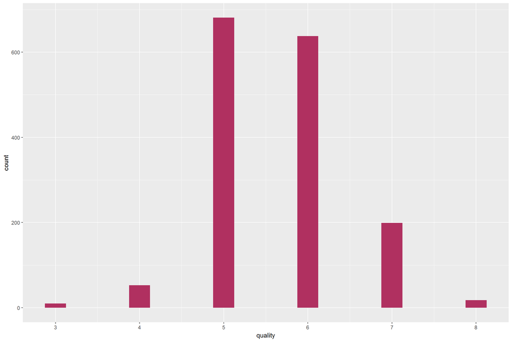

- From the graph and the summary statistics, we can infer that the distribution is almost normal with most wines having quality of 5 or 6.
- The lowest score is 3 and the highest score is 8.
- In our dataset, quality is a discrete variable while others are continuous.
- It would be easier to work with the dataset if quality was factored.

### Quality - Factored

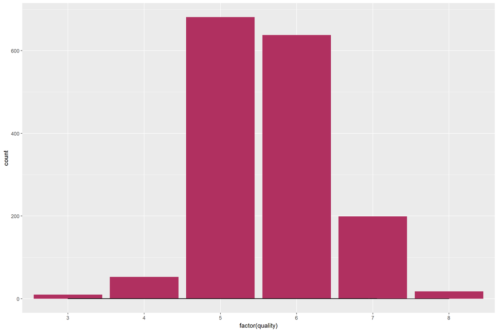

- Now that we have factored the quality variable, we can move on to other variables which affect the quality.

### Fixed Acidity

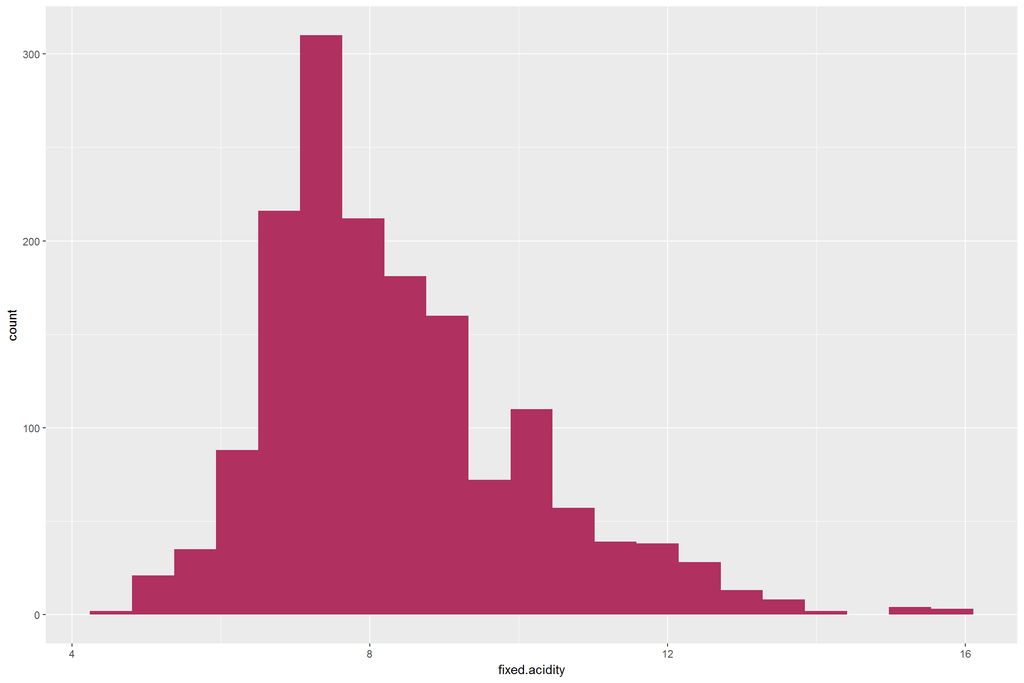

```
##    Min. 1st Qu.  Median    Mean 3rd Qu.    Max.
##    4.60    7.10    7.90    8.32    9.20   15.90
```

- Fixed acidity peaks around 7. Some wines have values over 14 though.

### Alcohol

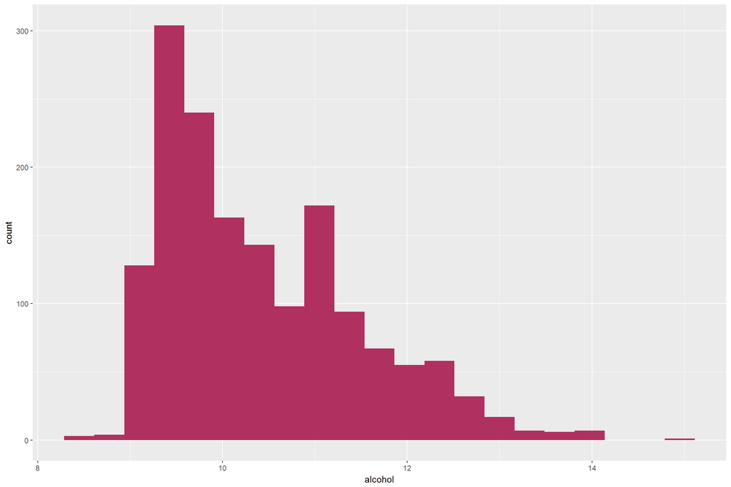

```
##    Min. 1st Qu.  Median    Mean 3rd Qu.    Max.
##    8.40    9.50   10.20   10.42   11.10   14.90
```

- Outlier - There seems to be an outlier with the value 14.9.
- The distribution is concentrated between 9 and 10.5

### pH

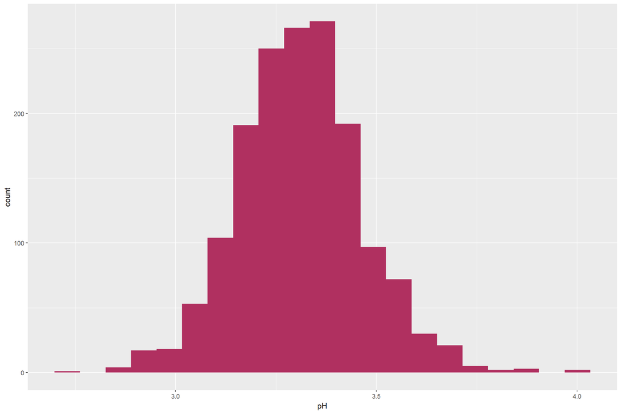

```
##    Min. 1st Qu.  Median    Mean 3rd Qu.    Max.
##   2.740   3.210   3.310   3.311   3.400   4.010
```

- A normal distribution is observed.
- There seem to be 2 outliers on each end of distribution.

### Volatile Acidity

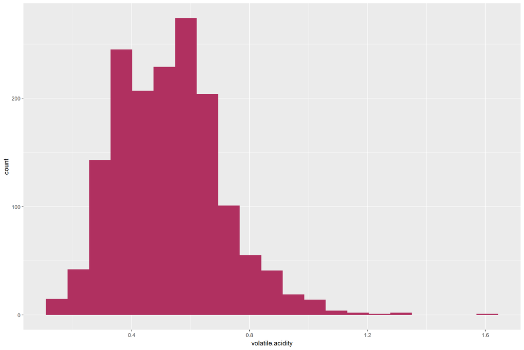

```
##    Min. 1st Qu.  Median    Mean 3rd Qu.    Max.
##  0.1200  0.3900  0.5200  0.5278  0.6400  1.5800
```

- There is a big difference between the 3rd quartile and the maximum value. This may be due to outliers.
- Let’s further analyze this by limiting the x-axis values.

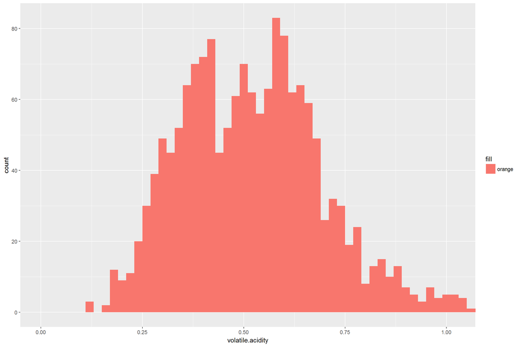

### Citric Acid

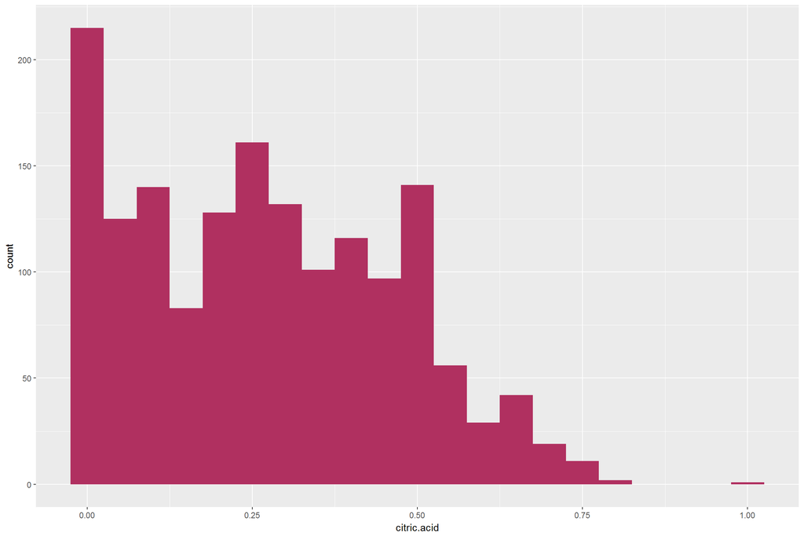

```
##    Min. 1st Qu.  Median    Mean 3rd Qu.    Max.
##   0.000   0.090   0.260   0.271   0.420   1.000
```

### Residual Sugar

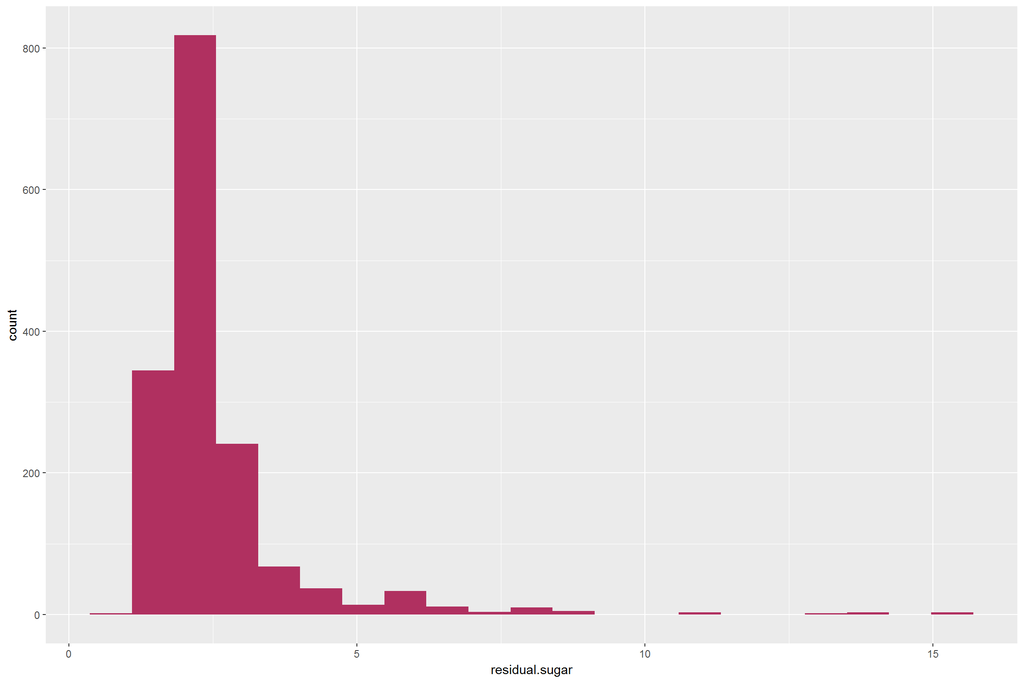

```
##    Min. 1st Qu.  Median    Mean 3rd Qu.    Max.
##   0.900   1.900   2.200   2.539   2.600  15.500
```

### Chloride

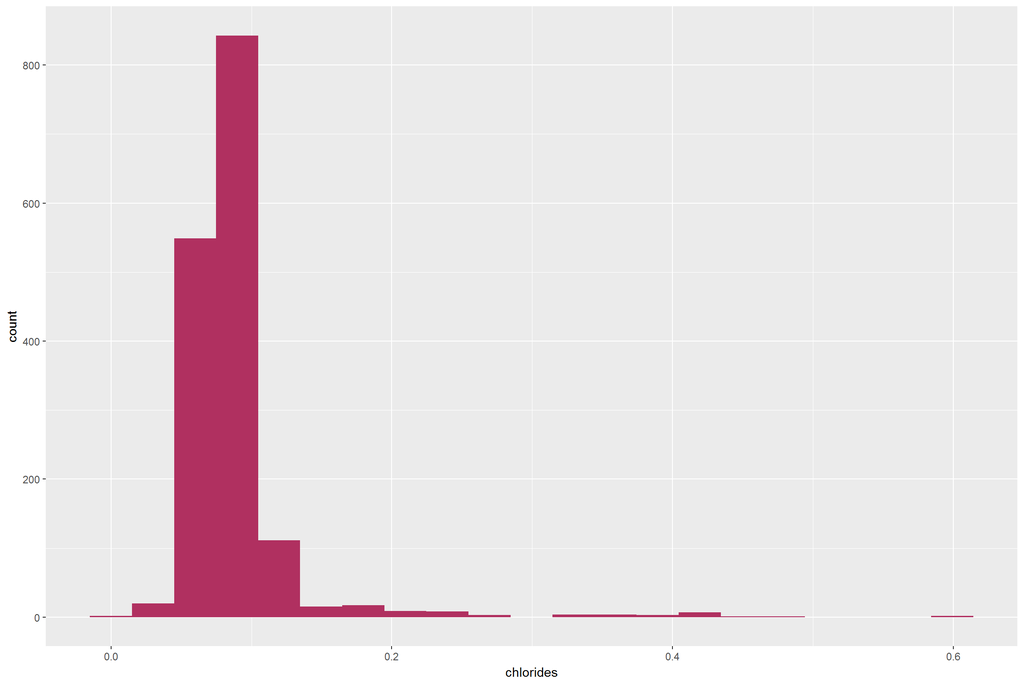

```
##    Min. 1st Qu.  Median    Mean 3rd Qu.    Max.
## 0.01200 0.07000 0.07900 0.08747 0.09000 0.61100
```

- SOme outliers are present

### Sulfur Dioxide

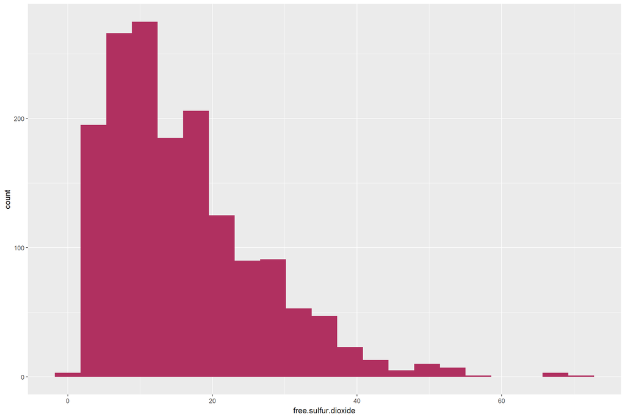

```
##    Min. 1st Qu.  Median    Mean 3rd Qu.    Max.
##    1.00    7.00   14.00   15.87   21.00   72.00
```

### Exclude Outliers

- The outliers for regular sugar and chlorides make it hard to see the shape of the distribution.
- Let’s remove the 95th percentile for residual sugar and chlorides.

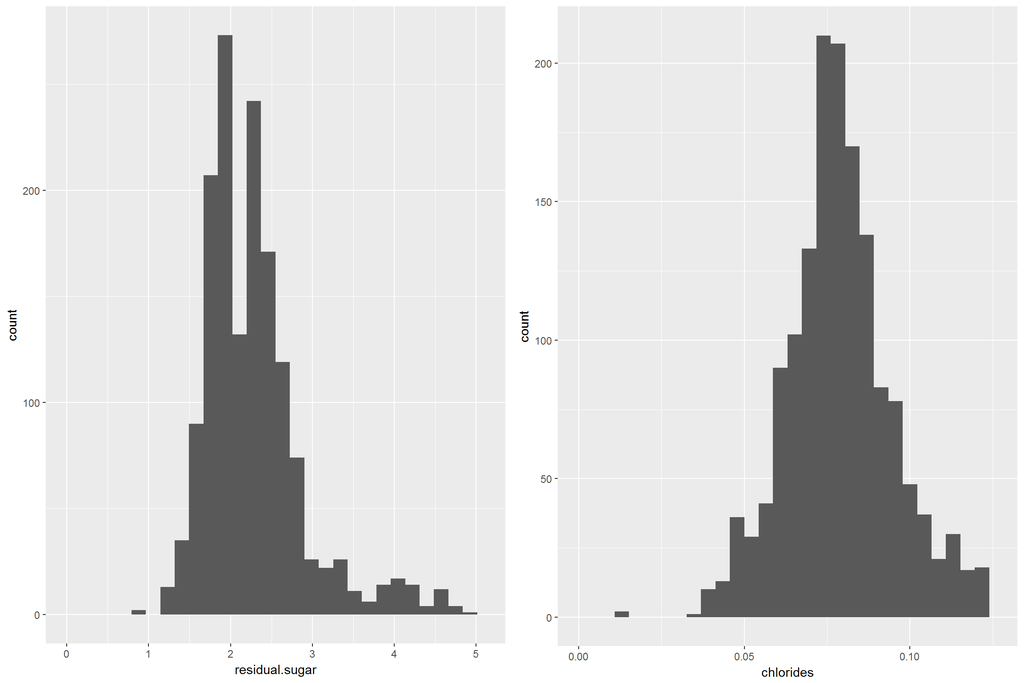

- As we can see, by removing the outliers we observe a normal distribution.

### Outlier Analysis

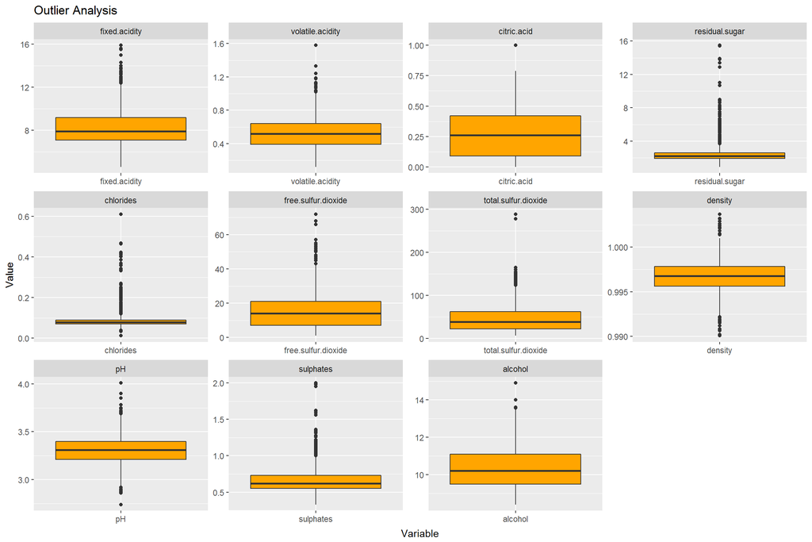

- Outliers are present for many vairbales.
- It appears that “Residual Sugar” and “Chlorides” have the most outliers.
- I will be focussing on these 2 for outlier removal.
- Log transformation can be applied to scale the distribution from skewed to normal.

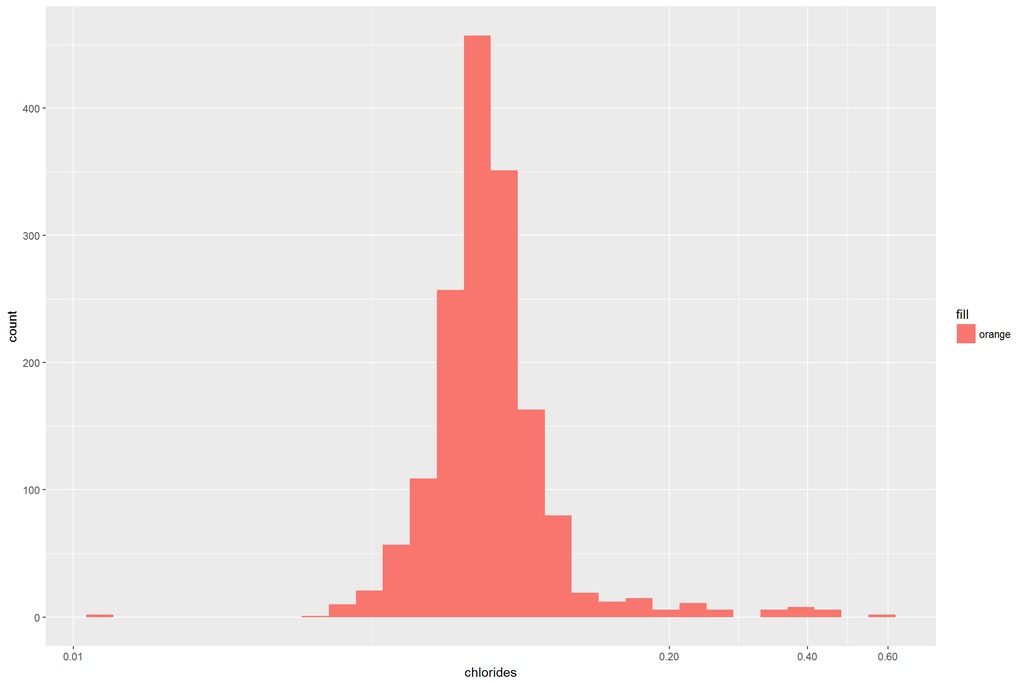

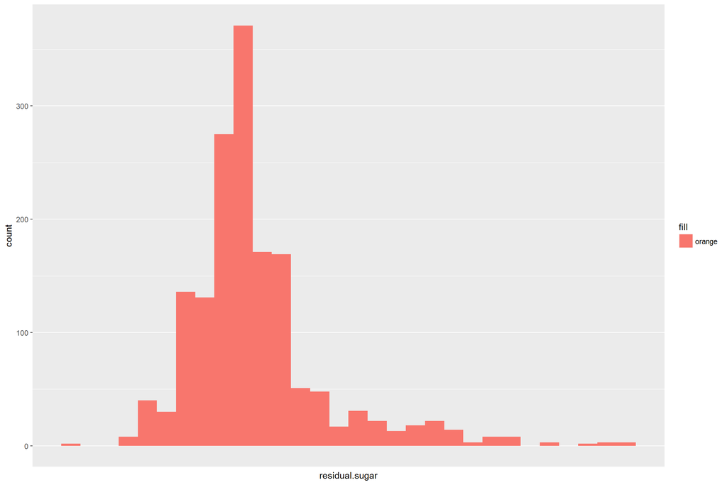

# Univariate Analysis

### What is the structure of your dataset?

The dataset contains 1599 obsevations with 12 continuous and 1 discrete variable. Input Variables: 1 - fixed acidity (tartaric acid - g / dm^3) 2 - volatile acidity (acetic acid - g / dm^3) 3 - citric acid (g / dm^3) 4 - residual sugar (g / dm^3) 5 - chlorides (sodium chloride - g / dm^3 6 - free sulfur dioxide (mg / dm^3) 7 - total sulfur dioxide (mg / dm^3) 8 - density (g / cm^3) 9 - pH 10 - sulphates (potassium sulphate - g / dm3) 11 - alcohol (% by volume) 12 - X ( index variable )

### What is/are the main feature(s) of interest in your dataset?

- The main feature of interest for this dataset is how to determine quality given the input variables.
- I will also try to detect relationships between input variables.
- I will try to determine which variables influence quality.

### What other features in the dataset do you think will help support your investigation into your feature(s) of interest?

These are the secondary features which may support by investigation: 1 - Alcohol 2 - Sulphates 3 - Citric Acid 4 - Volatile Acid

### Of the features you investigated, were there any unusual distributions? Did you perform any operations on the data to tidy, adjust, or change the form of the data? If so, why did you do this?

- I found some unusual distributions. I fixed them by performing outlier removal.

# Bivariate Plots Section

### Correlation Plot

- I will be using product-moment correlation to determine and visualize the relationship between 2 variables.
- The objective is to find out how variables affect quality and how one variable may affect another variable.

```
##  [1] "fixed.acidity"        "volatile.acidity"     "citric.acid"
##  [4] "residual.sugar"       "chlorides"            "free.sulfur.dioxide"
##  [7] "total.sulfur.dioxide" "density"              "pH"
## [10] "sulphates"            "alcohol"              "quality"
```

### Correlation Table:

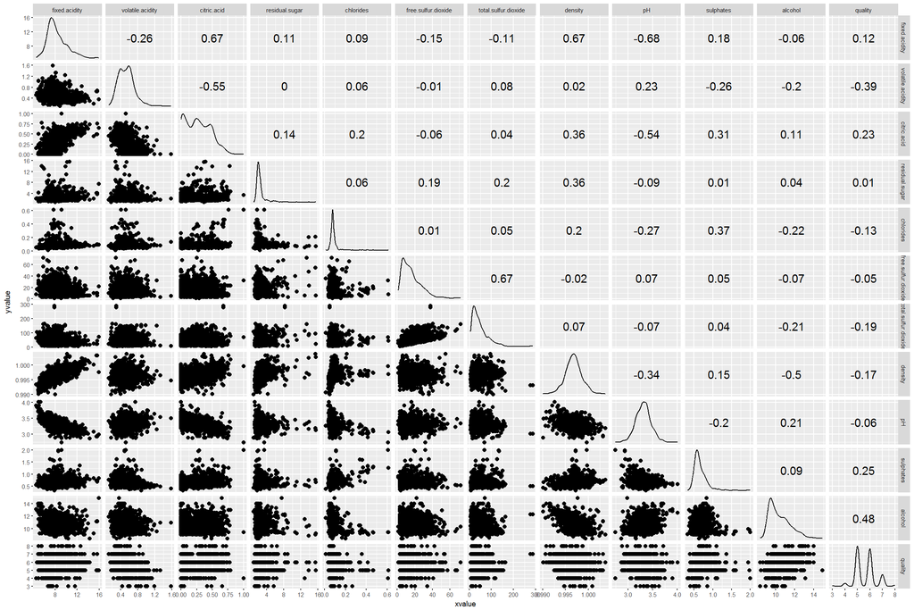

### Create correlation table with the help of corrplot.

```
- convert digital matrix to a graph
- display data vividly
- may help to find clusters in data
```

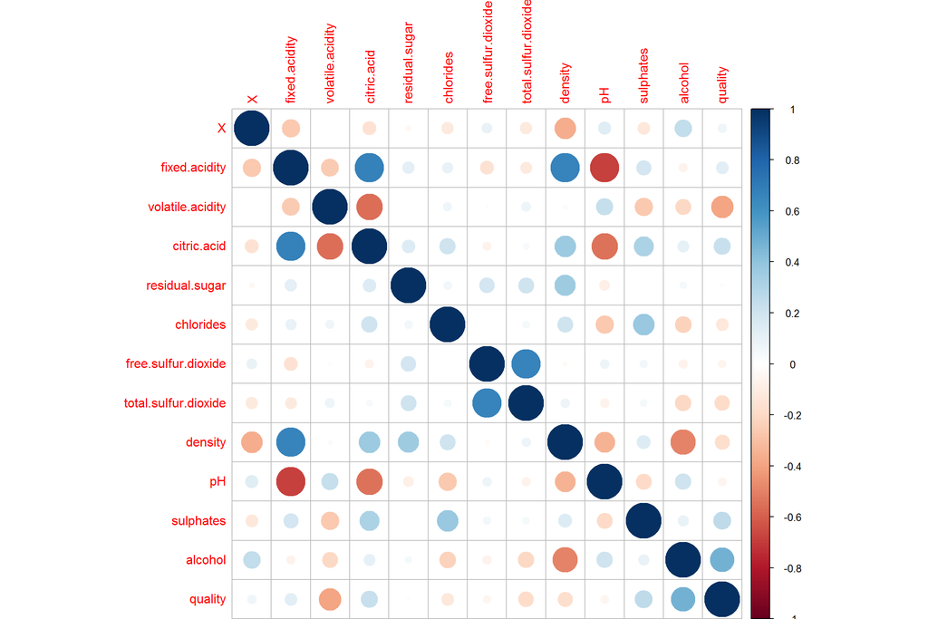

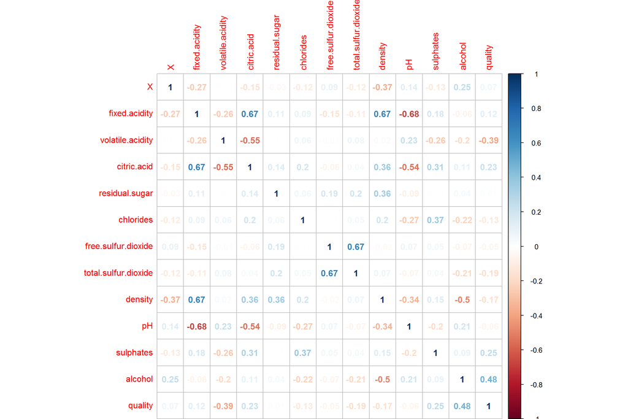

- The corrplot helps better visualize strong correlations.
- The variables with positive correlation to quality are:
  - alcohol:quality = 0.48
  - sulphates:quality = 0.25
  - citric.acid:quality = 0.23
  - fixed.acidity:quality = 0.12
  - residual sugar:quality = 0.01
- We see that alohol content and quality are closely related.
- The variables with negative correlation to quality are:
  - volatile.acidity:quality = -0.39
  - total.sulfur.dioxide:quality = -0.19
  - density:quality = -0.17
  - chlorides:quality = -0.13
- We see that volatile acidity of red wine and quality are inversely related.
- Variables with highest(+ve or -ve) correlation are:
  - fixed.acidity:citirc.acid = 0.67
  - fixed.acidity:density = 0.67
  - free.sulfur.dioxide:total.sulfur.dioxide = 0.67
  - alcohol:quality = 0.48
  - density:alcohol = -0.50
  - citric.acid:pH = -0.54
  - volatile.acidity:citirc.acid = -0.55
  - fixed.acidity:pH = -0.68

### Plot Aclohol and Wine Quality

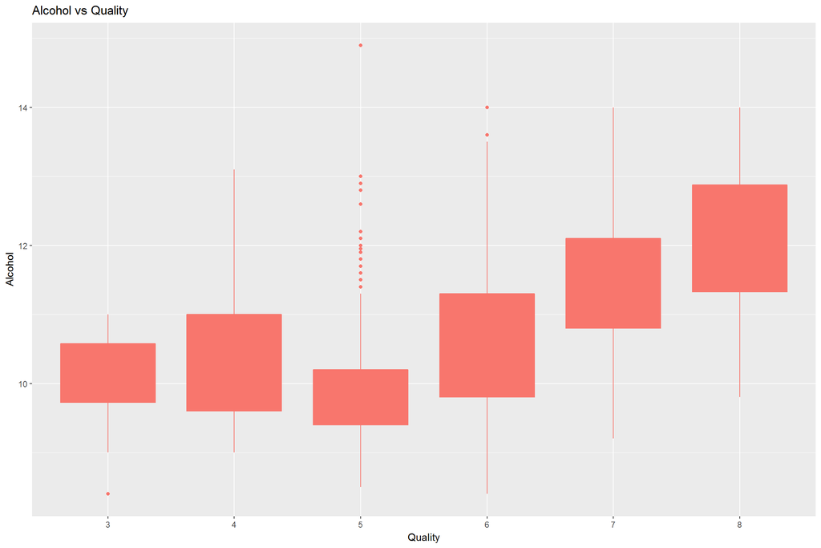

### Plot Volatile acidity vs Quality

[figure not shown]

### Plot Citric Acid vs Fixed Acidity

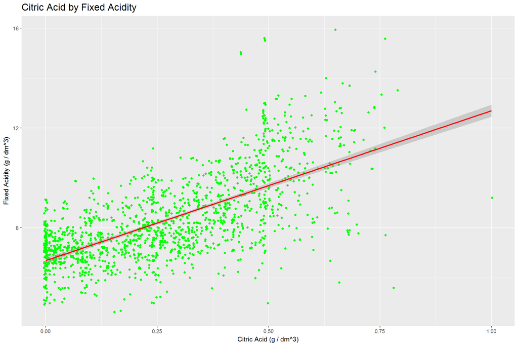

### Closer look at relationships

Lets summarise wine by volatile acidity:

```
## # A tibble: 6 x 6
##   quality mean_volatile_acidity median_volatile_acidity
##     <int>                 <dbl>                   <dbl>
## 1       3             0.8845000                   0.845
## 2       4             0.6939623                   0.670
## 3       5             0.5770411                   0.580
## 4       6             0.4974843                   0.490
## 5       7             0.4039196                   0.370
## 6       8             0.4233333                   0.370
## # ... with 3 more variables: var_volatile_acidity <dbl>,
## #   std_volatile_acidity <dbl>, n <int>
```

### Plot Free SO2 vs Total SO2

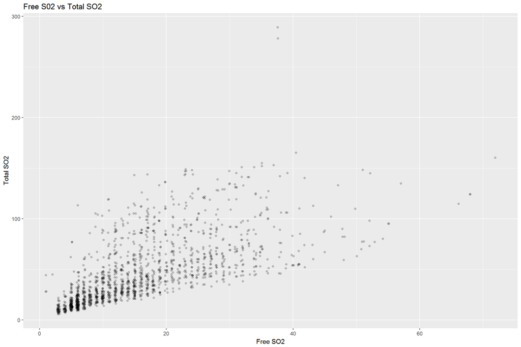

# Bivariate Analysis

### Talk about some of the relationships you observed in this part of the investigation. How did the feature(s) of interest vary with other features in the dataset?

-> Volatile Acidity - Shows negative correlation with quality and citric acid.

-> Free sulphur dioxide - High positive correlation with total sulphur dioxide and very little correlation with sulphates.

-> Quality - Positive correlation with alcohol and negative correlation with volatile acidity.

[output not shown]

### Did you observe any interesting relationships between the other features (not the main feature(s) of interest)?

- Yes, I observed a positive correlation for the following:
  - fixed.acidity:citirc.acid = 0.67
  - fixed.acidity:density = 0.67
  - free.sulfur.dioxide:total.sulfur.dioxide = 0.67
- Free SO2 vs Total SO2 graph validates the positive correlation between the 2 variables.

### What was the strongest relationship you found?

- Strongest relationship was found between: POsitive: - fixed.acidity : citirc.acid = 0.67 - fixed.acidity : density = 0.67 - free.sulfur.dioxide : total.sulfur.dioxide = 0.67 Negataive: - fixed.acidity : pH - volatile.acidity : citric.acid

# Multivariate Plots Section

### Plot the effect of volatile.acidity and alcohol on quality

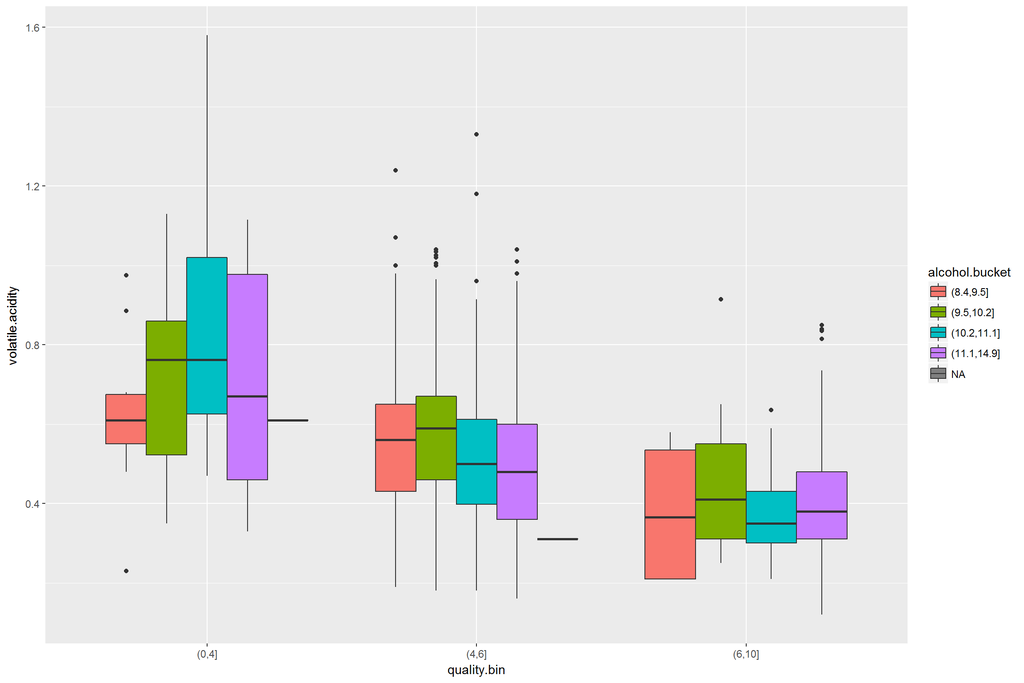

- It looks like wines with low to medium volatile acidity and medium to high alcohol content have better quality.
- Wines with high volatile acidity definitely have poor quality.

### Plot the effect of chlorides and sulphates on quality

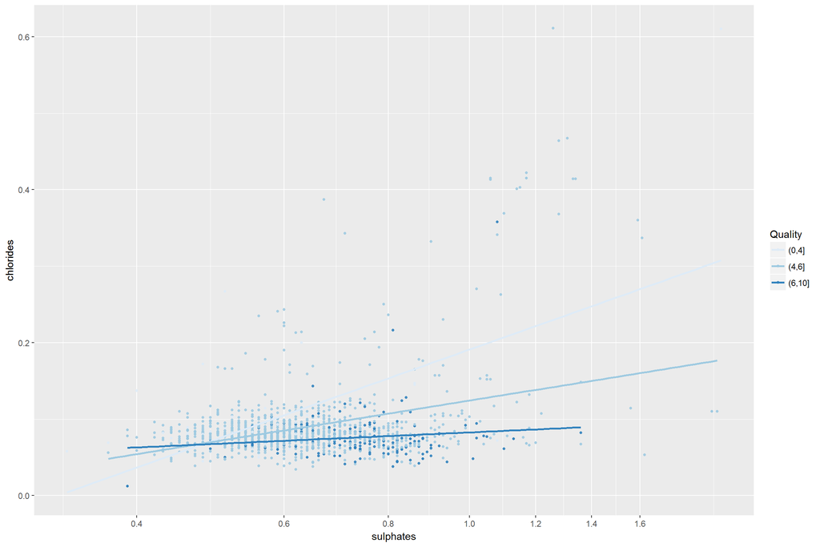

- The data points for medium quality wine is all over the graph. It is hard to determine a relationship here.
- It can be said thoug, if a wine has very lowe chloride and sulphate content then it would have poor quality as well.
- High quality wines sees to have medium suplhate and low choloride content.

### Plot affect of citric acid and alcohol on quality

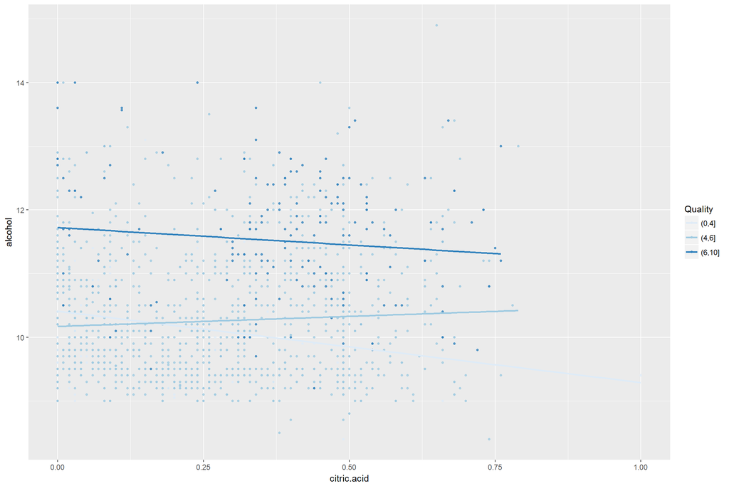

### Plot the effect of sulphates and alcohol

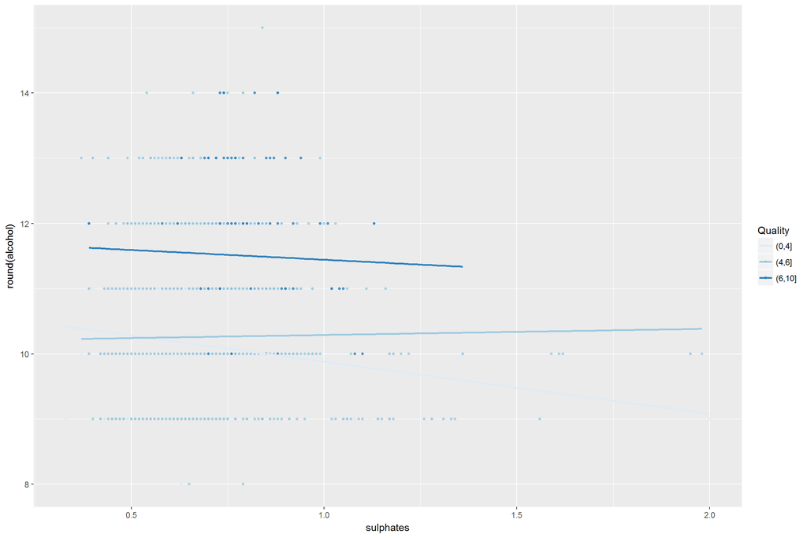

[figure not shown]

- High quality wines have high alcohol and medium sulphate value.
- Medium quality wine have low alochol and low sulphate value.
- Low quality wines typically have low alochol and a very low suplhate value.

# Multivariate Analysis

### Were there any interesting or surprising interactions between features?

- No one variable affects the quality of the wine.
- Usually, higher alcohol content has high quality.
- Wines with medium-high sulphate content, medium-high citric quality and low-medium volatile acidity have good wine quality.

# Final Plots and Summary

### Plot 1

### Alcohol and Quality have strong relationship. Let’s demonstrate this:

- By individual values:

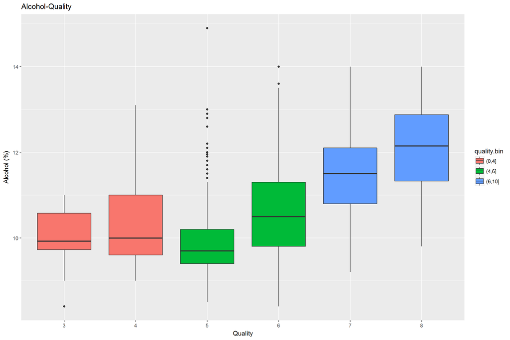

- Summary Statistics:

```
## wine$quality: 3
##    Min. 1st Qu.  Median    Mean 3rd Qu.    Max.
##   8.400   9.725   9.925   9.955  10.580  11.000
## --------------------------------------------------------
## wine$quality: 4
##    Min. 1st Qu.  Median    Mean 3rd Qu.    Max.
##    9.00    9.60   10.00   10.27   11.00   13.10
## --------------------------------------------------------
## wine$quality: 5
##    Min. 1st Qu.  Median    Mean 3rd Qu.    Max.
##     8.5     9.4     9.7     9.9    10.2    14.9
## --------------------------------------------------------
## wine$quality: 6
##    Min. 1st Qu.  Median    Mean 3rd Qu.    Max.
##    8.40    9.80   10.50   10.63   11.30   14.00
## --------------------------------------------------------
## wine$quality: 7
##    Min. 1st Qu.  Median    Mean 3rd Qu.    Max.
##    9.20   10.80   11.50   11.47   12.10   14.00
## --------------------------------------------------------
## wine$quality: 8
##    Min. 1st Qu.  Median    Mean 3rd Qu.    Max.
##    9.80   11.32   12.15   12.09   12.88   14.00
```

### Description 1

- I talked above how alcohol affects wine quality. It can be seen here that quality range 6-10 has higher median quality value versus other.
- There is one exception to the alcohol %. Wines with quality 5 tend to have lower alcohol percentage than wines with quality 3 and 4. This can be further explored.

### Plot 2

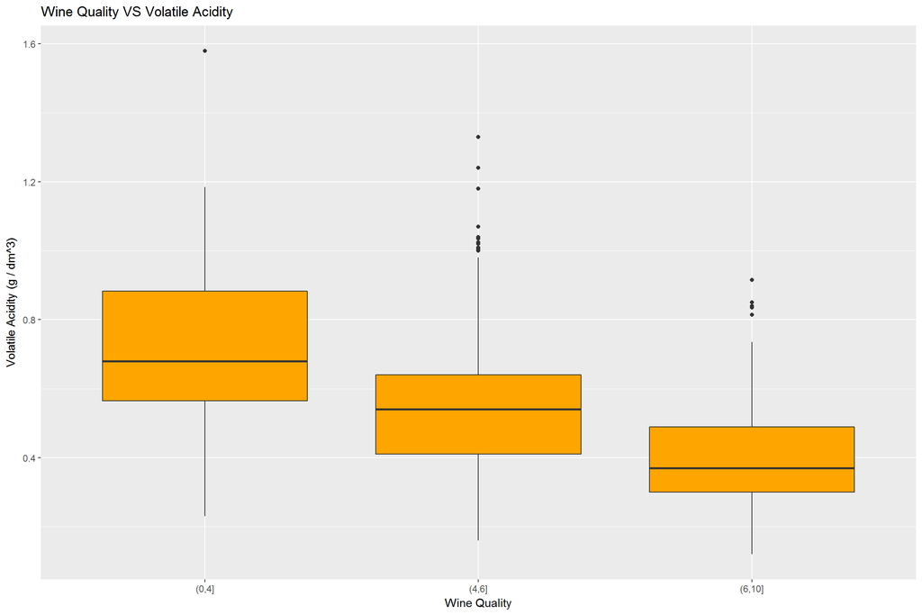

### Description 2

- High quality wines usualyy have low values of volatile acidity.
- Medium quality wines typically have medium value of volatile acidity. But many medium quality wines have high value of volatile acidity as well.
- Low quality wines have medium to high value for volatile acidity.

### Plot 3

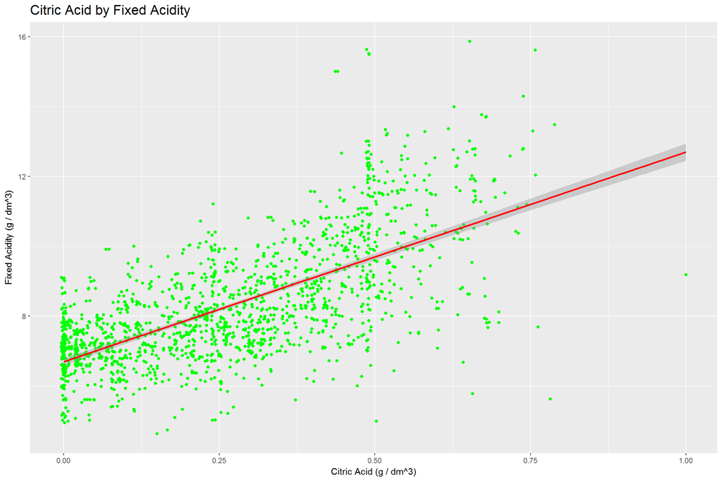

# Reflection

This was truly a very good case study to explore and understand univariate, bivariate and multivariate analysis. I started my exploration by first understanding the nature of the data and what values variables hold. Once I started exploring variables one at a time, I became more comfortable and intrigued with the dataset. Exploring one variable helped me develop a better understanding of the data. It was interesting to find out if one single variable can truely affect the quality of wine.

To better understand quality of wines, I factored quality into discrete variable by creating quality.bin. This helped in better categorization of wines. Then I moved on to bivariate analysis where I explored if any 2 variables have an effect on the quality of wine together.

I used the help of a correlation matrix to determine which variables I want to explore. I focussed my attention on the strong correlationship variables.

After performing bivariate analysis, I determined that wines with higher alcohol content in conjunction with medium-high sulphate content usually have higher quality.

TO further explore the relationships between variables, I performed multivariate analysis, where I assessed the main feature quality against 2 variables at a time. This helped determine if 2 variables in conjunction can have an effect on quality. I observed that volatile acidity and alcohol can help determine quality of the wine to an extent.

Multivariate analysis helped explore interesting relationships among variables.

The main limitations of the dataset is its age - the dataset is quite old. Also, the dataset is not global - it is limited to a region.

Future scope of this analysis can have: - Predictive modellinng of data where a model is fed 2 variables and quality is determined - Determining the set of variables which would help make a good predictive model. - The data can be extended to include more acedic values.